# BA Analytics report

joahn lab

2020-07-18

### Customer Satisfaction Data Analysis in US Airline Services

> Table of contents Abstract 1. Motivation 2. Data explanation 3. Analysis 3.1. Data exploration 3.1.1 Correlation coefficient 3.1.2. Simple linear regression 3.2. Data visualization 3.2.1. Non-Likert-scale factors on satisfaction 3.2.2. Likert-scale factors on satisfaction 3.3. Classification modelling 3.3.1. Tree model / RP, CI tree and Random forest models 3.3.2 Logistic regression model 4. Conclusion (omitted) 4.1. Algorithm recommendations (omitted) 4.2. Practical conclusion (omitted) *References

#### Abstract

With the development of the aviation industry in recent years, there has been surging needs for business analysis about customer convenience in flights, especially in the US. But the bottom line is within a year after this high reputation, in the crisis of this worldwide COVID-19 outbreak, all the airline services and the whole industry got a huge damage on their own businesses due to every country’s current travel restrictions and social distancing policies. So, what we have decided is to analyze how we can suggest to make airlines perform in a quite competitive manner. How will they fly again to risk this situation and attract their customers who want their needs to be satisfied? We analyzed the US airlines customer satisfaction dataset in several ways, following EDA, visualizations with ggplot(), and classification modelling to get more sense of satisfaction analysis. We want to help make breakthroughs now of crisis for airlines by harnessing the analysis skills we’ve learned from this class.

#### 1. Motivation

With the development of the aviation industry in recent years, there has been surging needs for business analysis about customer convenience in flights, especially in the US. According to an article called “Consumer satisfaction in the skies soars to record high in annual airline travel survey” published in CNBC last year, “2019 North American Airline Satisfaction Survey shows travelers gave the industry a record-high score, with the biggest improvements coming from so-called legacy carriers.” It is strongly sure that this improvement about proficiency in customer service has helped airlines record high sales. But the bottom line is within a year after this high reputation, in the crisis of this worldwide COVID-19 outbreak, all the airline services and the whole industry got a huge damage on their own businesses due to every country’s current travel restrictions and social distancing policies. As a matter of fact, [“Warren Buffett said Berkshire Hathaway sold its entire stakes in the four largest U.S. carriers as coronavirus devastates travel demand.”](https://www.cnbc.com/quotes/?symbol=BRK.A) last month. The four, which are well-known as four major airlines in US flight industries, “American”, “Delta”, “United”, “Southwest”, [“had posted their first quarterly losses in years, and warned of a slow recovery in demand from pre-pandemic levels. Even the CEO of Delta airlines said it could take 2 to 3 years from now.”](https://www.cnbc.com/2020/05/04/us-airline-stocks-tumble-after-buffett-sells-whole-stakes.html) And not surprisingly, carriers in South Korea suffer the similar situation in industry and businesses. So, what we have decided is to analyze how we can suggest to make airlines perform in a quite competitive manner. How will they fly again to risk this situation and attract their customers who want their needs to be satisfied? And moreover, how can this strategy be coordinated with the country’s travel restrictions and social distancing? We wanted to help make breakthroughs now of crisis for airlines by harnessing the analysis skills we’ve learned from this class.

#### 2. Data Explanation

```r
sf = read_xlsx("satisfaction.xlsx")
sf
```

```
## # A tibble: 129,880 x 24
##        id satisfaction_v2 Gender `Customer Type`   Age `Type of Travel` Class
##     <dbl> <chr>           <chr>  <chr>           <dbl> <chr>            <chr>
##  1  11112 satisfied       Female Loyal Customer     65 Personal Travel  Eco
##  2 110278 satisfied       Male   Loyal Customer     47 Personal Travel  Busi~
##  3 103199 satisfied       Female Loyal Customer     15 Personal Travel  Eco
##  4  47462 satisfied       Female Loyal Customer     60 Personal Travel  Eco
##  5 120011 satisfied       Female Loyal Customer     70 Personal Travel  Eco
##  6 100744 satisfied       Male   Loyal Customer     30 Personal Travel  Eco
##  7  32838 satisfied       Female Loyal Customer     66 Personal Travel  Eco
##  8  32864 satisfied       Male   Loyal Customer     10 Personal Travel  Eco
##  9  53786 satisfied       Female Loyal Customer     56 Personal Travel  Busi~
## 10   7243 satisfied       Male   Loyal Customer     22 Personal Travel  Eco
## # ... with 129,870 more rows, and 17 more variables: `Flight Distance` <dbl>,
## #   `Seat comfort` <dbl>, `Departure/Arrival time convenient` <dbl>, `Food and
## #   drink` <dbl>, `Gate location` <dbl>, `Inflight wifi service` <dbl>,
## #   `Inflight entertainment` <dbl>, `Online support` <dbl>, `Ease of Online
## #   booking` <dbl>, `On-board service` <dbl>, `Leg room service` <dbl>,
## #   `Baggage handling` <dbl>, `Checkin service` <dbl>, Cleanliness <dbl>,
## #   `Online boarding` <dbl>, `Departure Delay in Minutes` <dbl>, `Arrival Delay
## #   in Minutes` <dbl>
```

As suggested, out of 24 variables, 4 are continuous, 5 are nominal, and 14 are ordinal variables. And we should notice that these ordinal variables include 0, which means NA value out of scale of 1-5, to make sense of preprocessing NA values further. Basically, there has demographic information such as ‘Age’ and ‘Gender’. Moreover, customer type, class (of seats) and flight distance are noted, and additive information about flight delay is also suggested. Most importantly, ‘satisfaction_v2’ summarizes the overall satisfaction by customers who answered this questionnaire. We can guess that there might be correlation between this comprehensive variable and the other service evaluations variables.

#### 3. Data Analysis

##### 3.1. Data exploration

Let’s get down to summarizing our dataset with skimr::skim() function, which has a better performance than summary() function does.

```r
skimr::skim(sf)
```

Data summary

| Name | sf |
| --- | --- |
| Number of rows | 129880 |
| Number of columns | 24 |
| _______________________ |  |
| Column type frequency: |  |
| character | 5 |
| numeric | 19 |
| ________________________ |  |
| Group variables | None |

**Variable type: character**

| skim_variable | n_missing | complete_rate | min | max | empty | n_unique | whitespace |
| --- | --- | --- | --- | --- | --- | --- | --- |
| satisfaction_v2 | 0 | 1 | 9 | 23 | 0 | 2 | 0 |
| Gender | 0 | 1 | 4 | 6 | 0 | 2 | 0 |
| Customer Type | 0 | 1 | 14 | 17 | 0 | 2 | 0 |
| Type of Travel | 0 | 1 | 15 | 15 | 0 | 2 | 0 |
| Class | 0 | 1 | 3 | 8 | 0 | 3 | 0 |

**Variable type: numeric**

| skim_variable | n_missing | complete_rate | mean | sd | p0 | p25 | p50 | p75 | p100 | hist |
| --- | --- | --- | --- | --- | --- | --- | --- | --- | --- | --- |
| id | 0 | 1 | 64940.50 | 37493.27 | 1 | 32470.75 | 64940.5 | 97410.25 | 129880 | ▇▇▇▇▇ |
| Age | 0 | 1 | 39.43 | 15.12 | 7 | 27.00 | 40.0 | 51.00 | 85 | ▃▇▇▅▁ |
| Flight Distance | 0 | 1 | 1981.41 | 1027.12 | 50 | 1359.00 | 1925.0 | 2544.00 | 6951 | ▃▇▂▁▁ |
| Seat comfort | 0 | 1 | 2.84 | 1.39 | 0 | 2.00 | 3.0 | 4.00 | 5 | ▇▇▇▇▅ |
| Departure/Arrival time convenient | 0 | 1 | 2.99 | 1.53 | 0 | 2.00 | 3.0 | 4.00 | 5 | ▇▆▆▇▇ |
| Food and drink | 0 | 1 | 2.85 | 1.44 | 0 | 2.00 | 3.0 | 4.00 | 5 | ▇▇▇▇▆ |
| Gate location | 0 | 1 | 2.99 | 1.31 | 0 | 2.00 | 3.0 | 4.00 | 5 | ▆▆▇▇▅ |
| Inflight wifi service | 0 | 1 | 3.25 | 1.32 | 0 | 2.00 | 3.0 | 4.00 | 5 | ▃▇▇▇▇ |
| Inflight entertainment | 0 | 1 | 3.38 | 1.35 | 0 | 2.00 | 4.0 | 4.00 | 5 | ▃▃▅▇▆ |
| Online support | 0 | 1 | 3.52 | 1.31 | 0 | 3.00 | 4.0 | 5.00 | 5 | ▃▃▅▇▇ |
| Ease of Online booking | 0 | 1 | 3.47 | 1.31 | 0 | 2.00 | 4.0 | 5.00 | 5 | ▃▃▅▇▇ |
| On-board service | 0 | 1 | 3.47 | 1.27 | 0 | 3.00 | 4.0 | 4.00 | 5 | ▂▃▅▇▆ |
| Leg room service | 0 | 1 | 3.49 | 1.29 | 0 | 2.00 | 4.0 | 5.00 | 5 | ▂▅▅▇▇ |
| Baggage handling | 0 | 1 | 3.70 | 1.16 | 1 | 3.00 | 4.0 | 5.00 | 5 | ▁▂▅▇▆ |
| Checkin service | 0 | 1 | 3.34 | 1.26 | 0 | 3.00 | 3.0 | 4.00 | 5 | ▃▃▇▇▆ |
| Cleanliness | 0 | 1 | 3.71 | 1.15 | 0 | 3.00 | 4.0 | 5.00 | 5 | ▁▂▃▇▆ |
| Online boarding | 0 | 1 | 3.35 | 1.30 | 0 | 2.00 | 4.0 | 4.00 | 5 | ▃▅▇▇▇ |
| Departure Delay in Minutes | 0 | 1 | 14.71 | 38.07 | 0 | 0.00 | 0.0 | 12.00 | 1592 | ▇▁▁▁▁ |
| Arrival Delay in Minutes | 393 | 1 | 15.09 | 38.47 | 0 | 0.00 | 0.0 | 13.00 | 1584 | ▇▁▁▁▁ |

In this skim result, this dataset has similar shapes with normal distribution in ages and flight distances. Moreover, many of the respective satisfaction items have 3-4 in mean values, which implies that customers in general are satisfied with airline services overall. Because 5 Likert-scale variables do not count zero as applicable, there are no NA values instead, except for ‘Departure/Arrival delay in minutes’ concerned with special events like delay.

###### 3.1.1. Correlation coefficient

It is better to remain 0 values in 5 Likert-scale variables, rather than changing them with NA. It is because we cannot run correlation tests with numeric variables which have NA values. So, we didn’t consider preprocessing them. The coefficient tables with Pearson correlation tests are as follows.

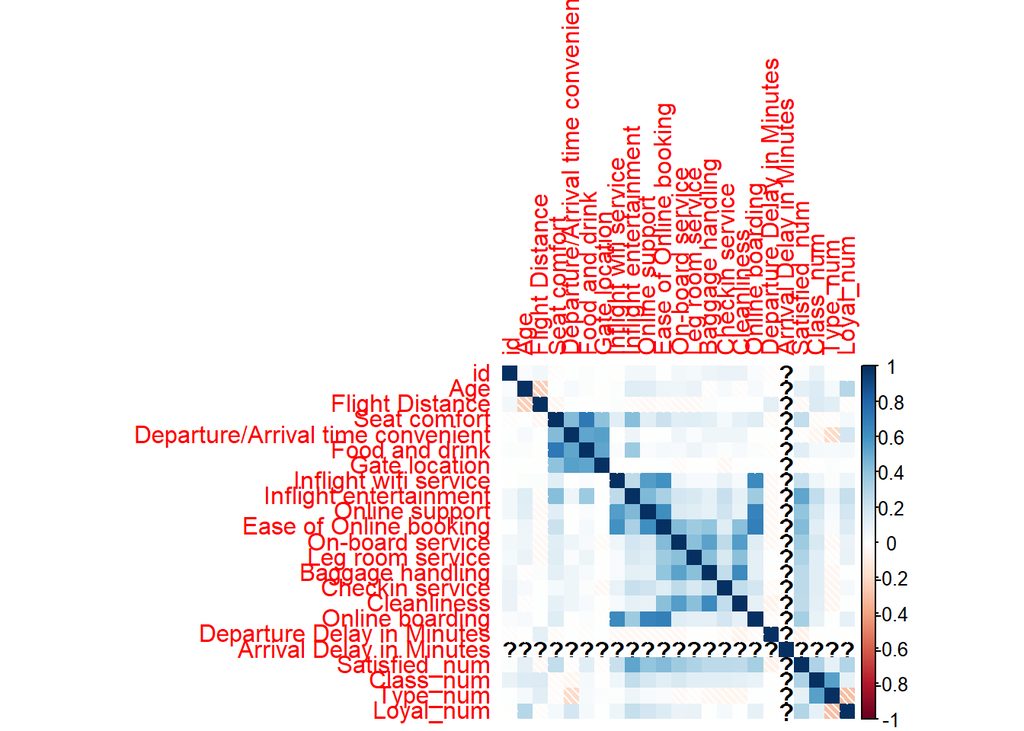

```r
sf.num = sf %>% mutate(Satisfied_num = ifelse(satisfaction_v2 == 'satisfied', 1, 0), Class_num = case_when(Class == 'Eco' ~ 0, Class == 'Eco Plus' ~ 1, Class == 'Business' ~ 2), Type_num = case_when(`Type of Travel` == 'Personal Travel' ~ 0, `Type of Travel` == 'Business travel' ~ 1), Loyal_num = ifelse(`Customer Type` == 'Loyal Customer', 1, 0))
sf.num = sf.num[, sapply(sf.num, is.numeric)]

corrplot::corrplot(cor(sf.num), method = "shade")
```

###### 3.1.2. Simple linear regression

With a simple linear regression test with lm() and tidy(), which summarizes the test in tibble, the result is as follows. The dependent variable is a dummy value labelled ‘Satisfied_num’, which counts 1 with ‘satisfied’ response, and 0 with ‘neutral or dissatisfied’ response.

```r
lm(Satisfied_num~., data = sf.num[,c(2:17, 20)]) %>% broom::tidy()
```

```
## # A tibble: 17 x 5
##    term                                   estimate std.error statistic   p.value
##    <chr>                                     <dbl>     <dbl>     <dbl>     <dbl>
##  1 (Intercept)                         -0.675        7.07e-3    -95.5  0.
##  2 Age                                  0.00104      7.42e-5     14.1  6.79e- 45
##  3 `Flight Distance`                   -0.00000238   1.07e-6     -2.22 2.62e-  2
##  4 `Seat comfort`                       0.0293       1.18e-3     24.9  1.51e-136
##  5 `Departure/Arrival time convenient` -0.0274       9.00e-4    -30.4  1.90e-202
##  6 `Food and drink`                    -0.0284       1.21e-3    -23.4  2.07e-120
##  7 `Gate location`                      0.0191       1.06e-3     18.0  2.51e- 72
##  8 `Inflight wifi service`             -0.0152       1.15e-3    -13.3  4.68e- 40
##  9 `Inflight entertainment`             0.141        1.05e-3    134.   0.
## 10 `Online support`                     0.0279       1.24e-3     22.5  1.78e-111
## 11 `Ease of Online booking`             0.0559       1.58e-3     35.4  9.54e-274
## 12 `On-board service`                   0.0503       1.12e-3     45.1  0.
## 13 `Leg room service`                   0.0380       9.68e-4     39.3  0.
## 14 `Baggage handling`                   0.00552      1.27e-3      4.34 1.44e-  5
## 15 `Checkin service`                    0.0377       9.27e-4     40.7  0.
## 16 Cleanliness                          0.00275      1.31e-3      2.09 3.65e-  2
## 17 `Online boarding`                    0.00724      1.34e-3      5.40 6.76e-  8
```

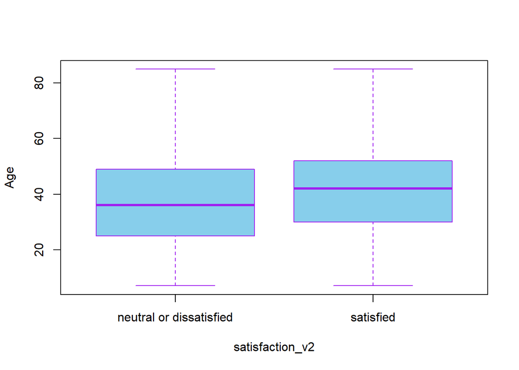

```r
boxplot(Age~satisfaction_v2, data = sf, col = "sky blue", border= "purple")
```

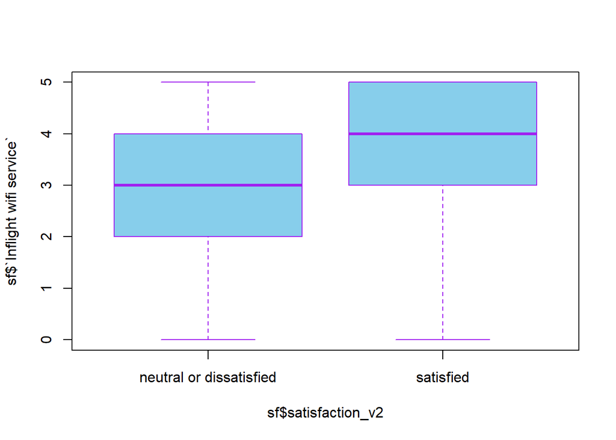

```r
boxplot(sf$`Inflight wifi service`~sf$satisfaction_v2, data = sf, col = "sky blue", border= "purple")
```

##### 3.2. Data visualization

With EDA above, we found some interesting insights on this dataset. Now we want to articulate these tendencies into ggplot graphs with sophisticated visualizations. What we want here is to make clear which factors ‘satisfaction _v2’, key value in this dataset which stands for customer satisfaction, has much to do with. Here are checklists we would like to confirm, based on some interesting insights suggested above in the last part.

###### 3.2.1. Non-likert scale factors on satisfaction

We already saw that ‘Type of Travel’, ‘Flight distances’ and ‘Customer Type’ has to do with overall satisfaction variables. Therefore, we may look closely at these relationships with geom_bar() and geom_histogram().

###### (a) Type of travel/Customer type on satisfaction

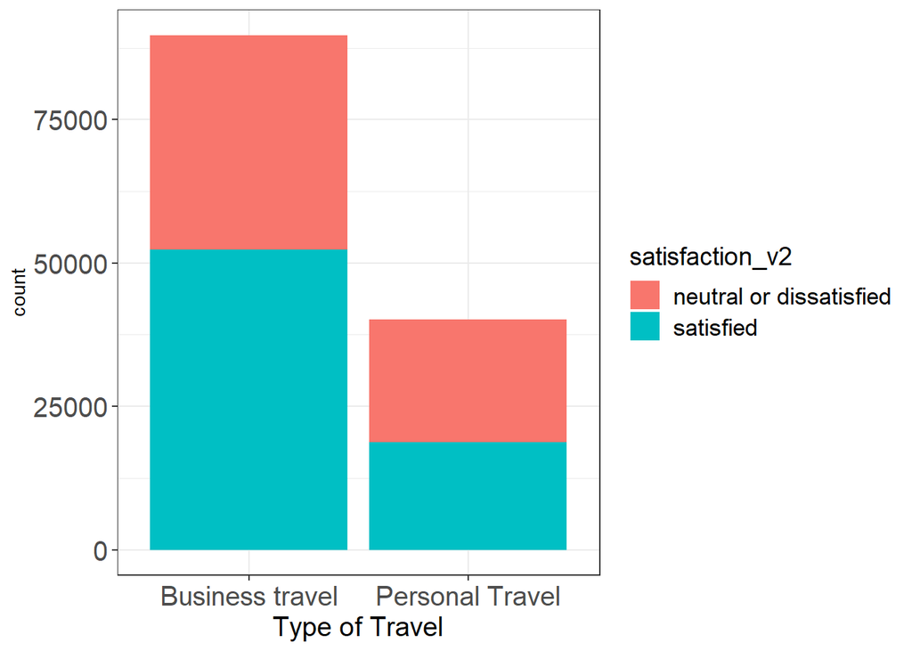

```r
sf %>%
  ggplot(aes(x = `Type of Travel`, fill = satisfaction_v2)) +
  geom_bar(aes(x = `Type of Travel`))+
  theme_bw()+
  theme(axis.title.x = element_text(size = 15),
        axis.text = element_text(size = 15),
        legend.title = element_text(size = 14),
        legend.text = element_text(size = 13))
```

As you see above, Business travelers have satisfied more than personal travels have, and we can easily see the proportional differences in color between two groups.

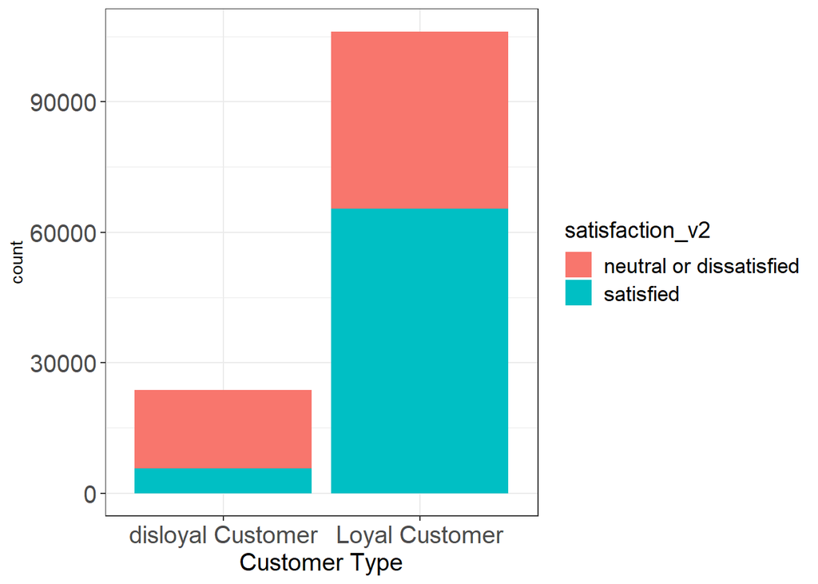

```r
sf %>%
  ggplot(aes(fill = satisfaction_v2)) +
  geom_bar(aes(x = `Customer Type`)) +
  theme_bw() +
  theme(axis.title.x = element_text(size = 15),
        axis.text = element_text(size = 15),
        legend.title = element_text(size = 14),
        legend.text = element_text(size = 13))
```

In this graph, although we notice that there are much more loyal customers counted, it is reported that loyal customers tend to be much more satisfied with overall services than their counterparts.

###### (b) Flight distances on satisfaction

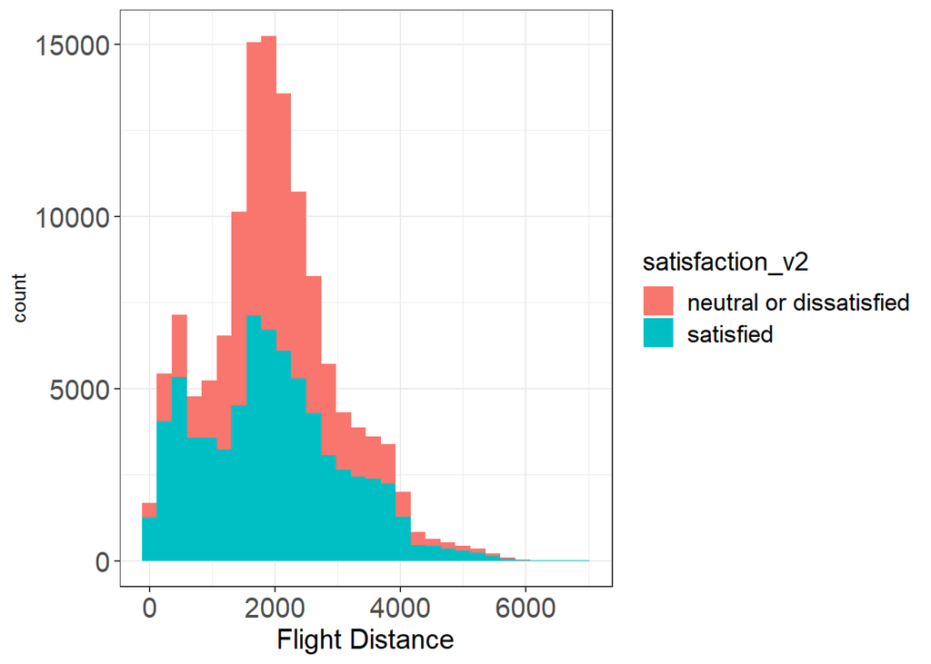

```r
sf %>%
  ggplot(aes(x = `Flight Distance`, fill = satisfaction_v2)) +
  geom_histogram() +
  theme_bw()+
  theme(axis.title.x = element_text(size = 15),
        axis.text = element_text(size = 15),
        legend.title = element_text(size = 14),
        legend.text = element_text(size = 13))
```

In this histogram suggesting counts on continuous flight distances, we find that only from 1000 to 3000km long, where most customers are covered, satisfaction level is similar with each other while customers are likely to report satisfaction in other ranges. Therefore, it is hard to simply suggest a linear relationship between flight distances and overall satisfaction.

###### 3.2.2. Likert-scale factors on satisfaction

We will focus on two Likert-scale factors, which were reported to have a negative relationship with overall satisfaction. It does not make sense to general thinking, and after looking at the graph we made, we will decide if it is better to get rid of these variables out of model.

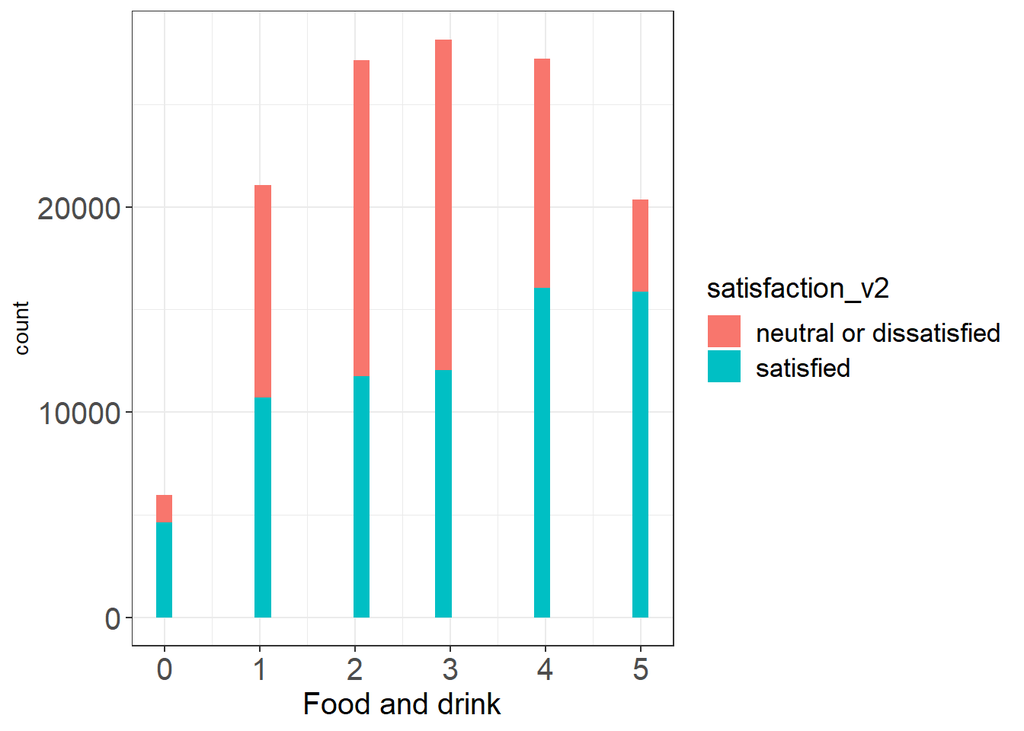

```r
sf %>%
  ggplot(aes(x = `Food and drink`, fill = satisfaction_v2)) +
  geom_histogram() +
  theme_bw()+
  theme(axis.title.x = element_text(size = 15),
        axis.text = element_text(size = 15),
        legend.title = element_text(size = 14),
        legend.text = element_text(size = 13))
```

The first one is ‘Food and drink’ satisfaction item. There is a slight increase in proportion of ‘satisfied’ customers in 4-5 point. However, we couldn’t see a clear estimate in EDA, due to 1-3 points where there is no increase in proportion of ‘satisfied’ customers. We can guess as ‘food and drink’ is available at such level, people don’t much care about this item. But since this variable doesn’t seem to harm classification modelling, we can keep that in later models.

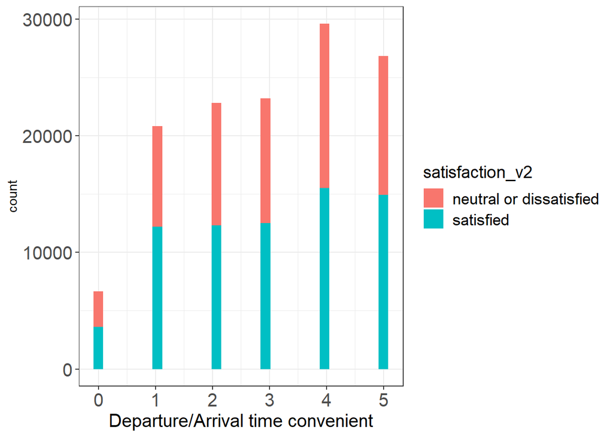

```r
sf %>%
  ggplot(aes(x = `Departure/Arrival time convenient`, fill = satisfaction_v2)) +
  geom_histogram() +
  theme_bw()+
  theme(axis.title.x = element_text(size = 15),
        axis.text = element_text(size = 15),
        legend.title = element_text(size = 14),
        legend.text = element_text(size = 13))
```

The second one is ‘Departure/Arrival time convenient’ variable. There shows a similar tendency as ‘Food and drink’. It means that, if they are not so bothered with inconvenience of unpunctuality, they don’t find this variable as important for their satisfaction. However, there is a slight and positive tendency as we see on the graph, which might help classify ‘satisfied’ customers in later models. So, we can keep these two Likert-scale variables.

##### 3.3. Classification modelling

###### 3.3.1. Tree model / RP, CI tree and Random forest models

```r
##########
# RP tree
##########

set.seed(1234) # I checked for 3 seeds, '1234', '1000', '4321'
index = sample(2, nrow(sf), replace = TRUE, prob = c(0.7, 0.3))
trainset = sf[index==1,]
testset = sf[index==2,]
dim(trainset)
```

```
## [1] 90994    24
```

```r
dim(testset)
```

```
## [1] 38886    24
```

```r
sf.rp = rpart::rpart(satisfaction_v2~., data = trainset)
sf.rp
```

```
## n= 90994
##
## node), split, n, loss, yval, (yprob)
##       * denotes terminal node
##
##  1) root 90994 41097 satisfied (0.451645163 0.548354837)
##    2) Inflight entertainment< 3.5 40684  8808 neutral or dissatisfied (0.783502114 0.216497886)
##      4) Seat comfort< 3.5 35562  5178 neutral or dissatisfied (0.854395141 0.145604859)
##        8) Seat comfort>=0.5 33707  3331 neutral or dissatisfied (0.901177797 0.098822203) *
##        9) Seat comfort< 0.5 1855     8 satisfied (0.004312668 0.995687332) *
##      5) Seat comfort>=3.5 5122  1492 satisfied (0.291292464 0.708707536) *
##    3) Inflight entertainment>=3.5 50310  9221 satisfied (0.183283641 0.816716359)
##      6) Ease of Online booking< 3.5 13801  5674 satisfied (0.411129628 0.588870372)
##       12) Inflight entertainment< 4.5 9381  4294 neutral or dissatisfied (0.542266283 0.457733717)
##         24) Online support< 4.5 8110  3222 neutral or dissatisfied (0.602712700 0.397287300) *
##         25) Online support>=4.5 1271   199 satisfied (0.156569630 0.843430370) *
##       13) Inflight entertainment>=4.5 4420   587 satisfied (0.132805430 0.867194570) *
##      7) Ease of Online booking>=3.5 36509  3547 satisfied (0.097154126 0.902845874) *
```

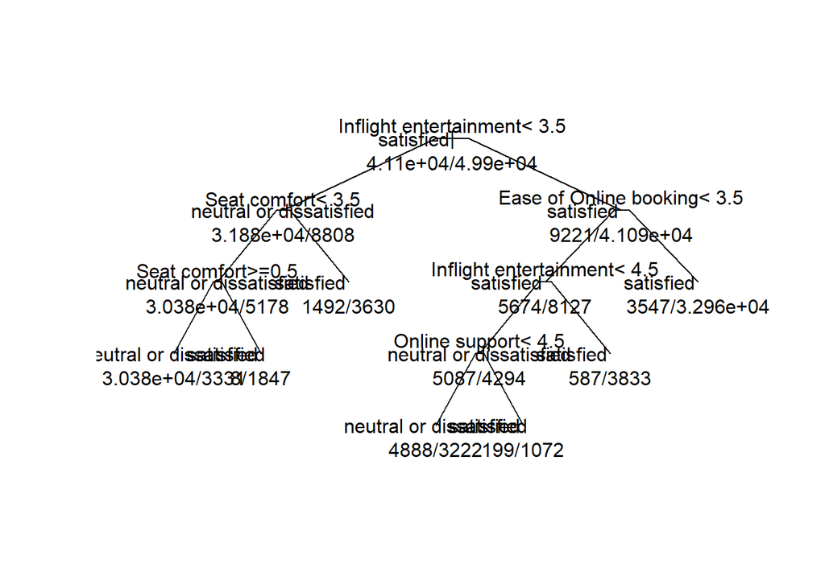

```r
plot(sf.rp, uniform=TRUE, branch=0.1, margin=0.1)
text(sf.rp, all=TRUE, use.n=TRUE)
```

```r
predictions = predict(sf.rp, testset, type="class")
table(predictions, testset$satisfaction_v2)
```

```
##
## predictions               neutral or dissatisfied satisfied
##   neutral or dissatisfied                   15191      2749
##   satisfied                                  2505     18441
```

```r
confusionMatrix(table(predictions, testset$satisfaction_v2))
```

```
## Confusion Matrix and Statistics
##
##
## predictions               neutral or dissatisfied satisfied
##   neutral or dissatisfied                   15191      2749
##   satisfied                                  2505     18441
##
##                Accuracy : 0.8649
##                  95% CI : (0.8614, 0.8683)
##     No Information Rate : 0.5449
##     P-Value [Acc > NIR] : < 2.2e-16
##
##                   Kappa : 0.7279
##
##  Mcnemar's Test P-Value : 0.000801
##
##             Sensitivity : 0.8584
##             Specificity : 0.8703
##          Pos Pred Value : 0.8468
##          Neg Pred Value : 0.8804
##              Prevalence : 0.4551
##          Detection Rate : 0.3907
##    Detection Prevalence : 0.4613
##       Balanced Accuracy : 0.8644
##
##        'Positive' Class : neutral or dissatisfied
##
```

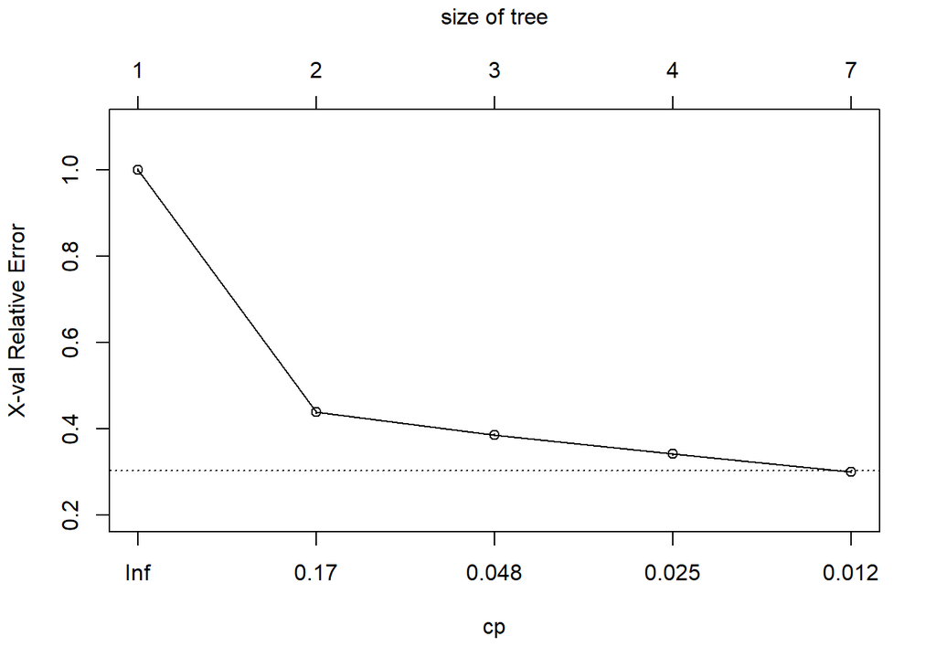

```r
rpart::plotcp(sf.rp)
```

```r
##########
# CI tree
##########

# Pre-processing before prdictions

sf$satisfaction_v2 = as.factor(sf$satisfaction_v2)
sf$Gender= as.factor(sf$Gender)
sf$`Customer Type` = as.factor(sf$`Customer Type`)
sf$`Type of Travel` = as.factor(sf$`Type of Travel`)
sf$Class = as.factor(sf$Class)

sf.name = sf %>% colnames() %>% str_replace_all(" ","")
sf.df.name = sf %>% setNames(sf.name)

trainset.ci = sf[index==1,]
testset.ci = sf[index==2,]

sf.ci = ctree(satisfaction_v2 ~ ., data=trainset.ci)
# sf.ci
# plot(sf.ci)

predictions = predict(sf.ci, testset.ci)
table(predictions, testset.ci$satisfaction_v2)
```

```
##
## predictions               neutral or dissatisfied satisfied
##   neutral or dissatisfied                   16621      1263
##   satisfied                                  1075     19927
```